# Evaluation_100x25

Kento Okuyama

2024-02-23

## (very) Brief introduction

In this document, we evaluate the implementation of our frequentist implementation of the non-linear regime-switching state-space (RSSS) model estimation based on simulated data. Our implementation is a special case in which the regime-switch occurs only in one direction (i.e., there’s no switch back). Our parameter optimization consists of 300 iteration steps based on Adam and 30 initializations of the starting parameter values.

In our implementation, our objective function **sumLik** is maximized based on the gradient vector and Adam. For evaluation purpose, we also have the score function **delta**. This is simply calculated as the summed squared error of the one-step-ahead (of the last observed time points) prediction of our intra-individual latent variables. Further, we also have **sensitivity** and **specificity** based on the one-step-ahead regime prediction results.

### N=100, T=25

```
## <environment: R_GlobalEnv>
```

```
## <environment: R_GlobalEnv>
```

Before starting the evaluation of our estimated results, let’s take a look at the simulated data. We are particularly interested in the regime-switch occurence. We will summarize the percentage of subjects who made a regime switch in each of simulated realizations.

```
## <environment: R_GlobalEnv>
```

```
## <environment: R_GlobalEnv>
```

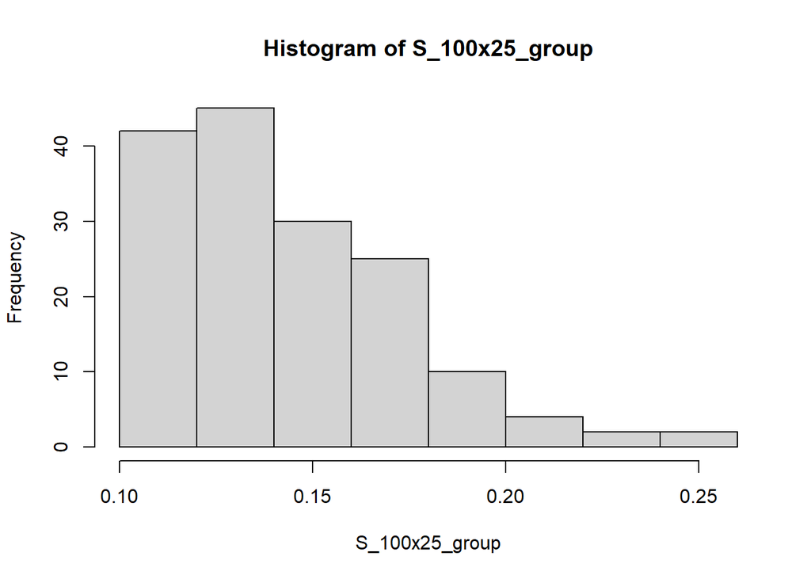

```
##    Min. 1st Qu.  Median    Mean 3rd Qu.    Max.
##  0.1000  0.1200  0.1400  0.1458  0.1700  0.2600
```

```
## [1] 160
```

First, we check the distribution of the resulting **sumLik** in log scale.

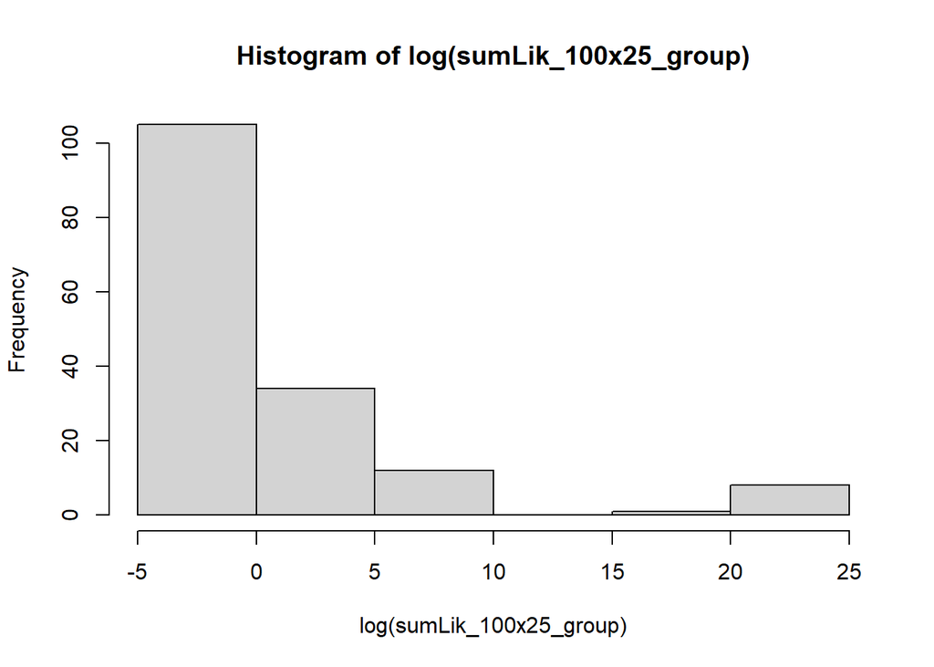

```
##     Min.  1st Qu.   Median     Mean  3rd Qu.     Max.
## -4.16730 -3.26583 -2.68855  0.07851  1.25725 22.85600
```

It seems like there are a few instances which has much higher **sumLik** than others.

Second, we check the distribution of the resulting **delta** in log scale.

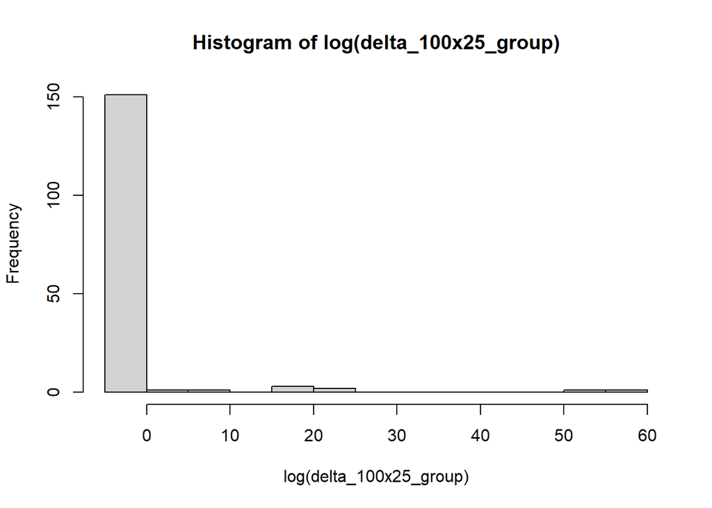

```
##     Min.  1st Qu.   Median     Mean  3rd Qu.     Max.
## -1.96767 -1.53869 -1.34859  0.06124 -1.13433 55.37433
```

Please note that we prefer a smaller value as it is calculated based on the prediction error.

Next, we turn our attention to how the **sumLik** and **delta** correlate (in log scale). Intuitively, we expect the negative correlation so that higher **sumLik** (maximized likelihood) relates to smaller **delta** (smaller prediction error).

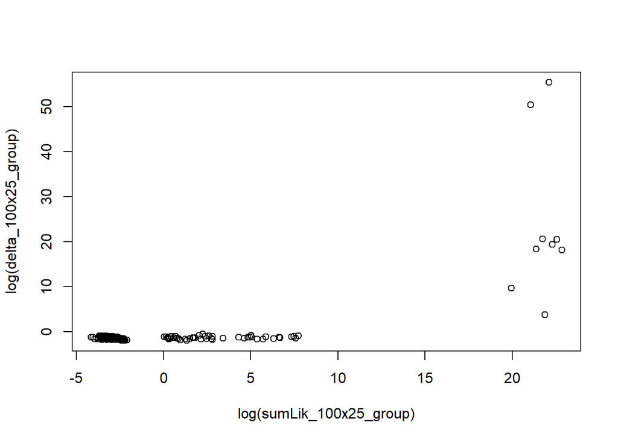

```
## [1] 0.7267369
```

Then, we check the distribution of **sensitivity** and **specificity**. First for **sensitivity**

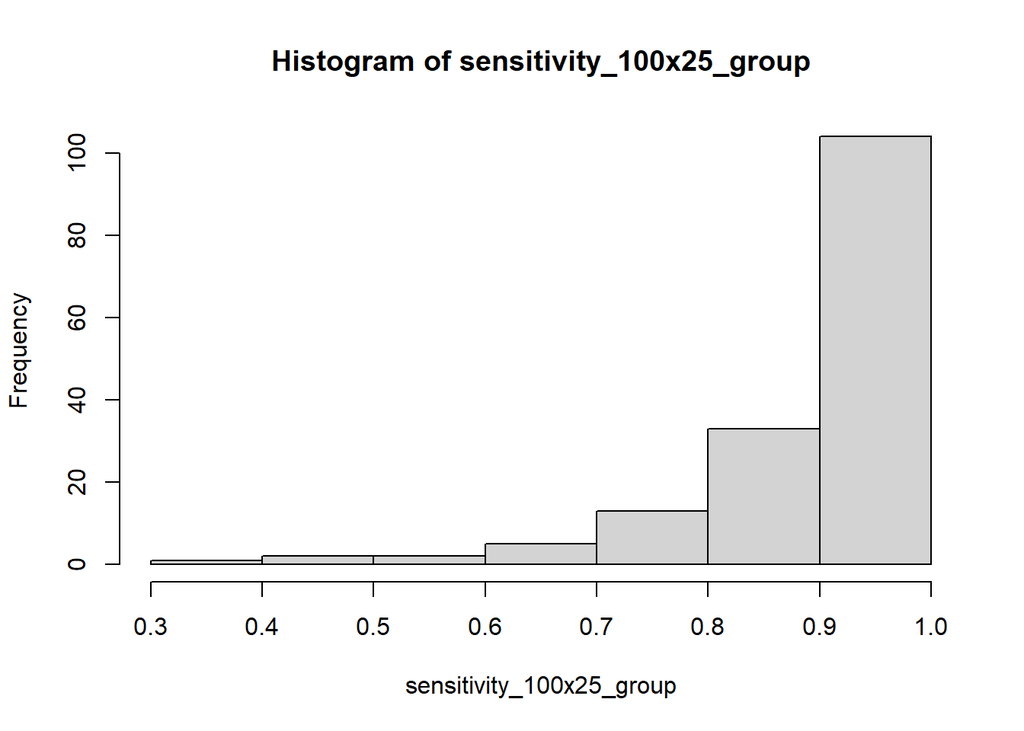

```
##    Min. 1st Qu.  Median    Mean 3rd Qu.    Max.
##  0.3684  0.8824  0.9375  0.9133  1.0000  1.0000
```

```
## [1] 0.14375
```

And for **specificity**

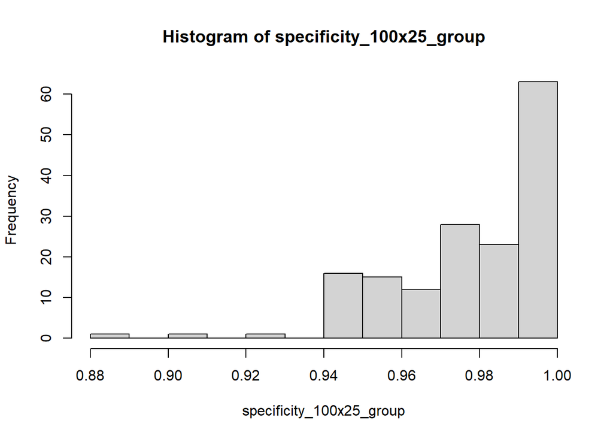

```
##    Min. 1st Qu.  Median    Mean 3rd Qu.    Max.
##  0.8876  0.9659  0.9882  0.9801  1.0000  1.0000
```

We can also check the correlation between **sensitivity** and **specificity**.

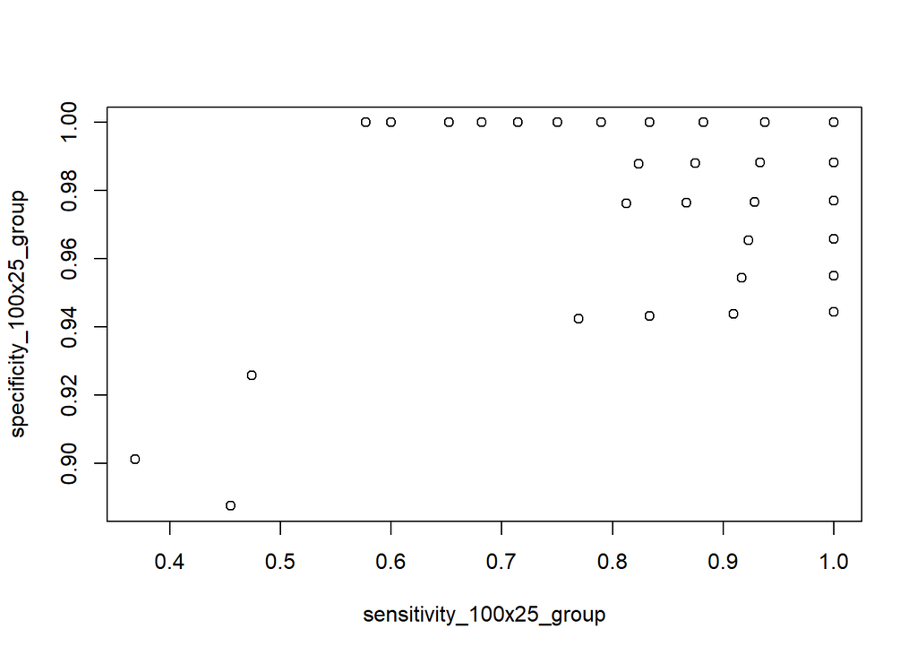

```
## [1] -0.02554355
```

Finally we examine our parameter estimation. The distribution of parameter estimation are shown below. True parameter values are in parenthesis.

```
##    B11_1 (.2)         B11_2 (.3)        B12_1 (-.1)       B12_2 (-.2)
##  Min.   :-0.01528   Min.   :-0.01651   Min.   :-0.6261   Min.   :-0.53039
##  1st Qu.: 0.08216   1st Qu.: 0.12862   1st Qu.:-0.2302   1st Qu.:-0.26381
##  Median : 0.13185   Median : 0.19659   Median :-0.1460   Median :-0.17652
##  Mean   : 0.16406   Mean   : 0.21964   Mean   :-0.1673   Mean   :-0.18653
##  3rd Qu.: 0.18528   3rd Qu.: 0.28144   3rd Qu.:-0.0907   3rd Qu.:-0.09429
##  Max.   : 0.77047   Max.   : 0.62777   Max.   : 0.0535   Max.   : 0.12856
##   B21d_1 (.8)      B21d_2 (.8)      B22d_1 (.4)        B22d_2 (.4)
##  Min.   :0.4929   Min.   :0.5361   Min.   :-0.01191   Min.   :-0.02454
##  1st Qu.:0.7523   1st Qu.:0.7925   1st Qu.: 0.14234   1st Qu.: 0.10872
##  Median :0.8323   Median :0.8576   Median : 0.25695   Median : 0.22395
##  Mean   :0.8146   Mean   :0.8346   Mean   : 0.24055   Mean   : 0.21741
##  3rd Qu.:0.8868   3rd Qu.:0.8993   3rd Qu.: 0.35225   3rd Qu.: 0.33784
##  Max.   :1.0005   Max.   :1.0932   Max.   : 0.48244   Max.   : 0.47801
##    B31_1 (.1)          B31_2 (.1)        B32_1 (-.1)        B32_2 (-.1)
##  Min.   :-0.488528   Min.   :-0.38338   Min.   :-0.49202   Min.   :-0.51070
##  1st Qu.: 0.002254   1st Qu.:-0.01410   1st Qu.:-0.13249   1st Qu.:-0.13905
##  Median : 0.046325   Median : 0.05034   Median :-0.07914   Median :-0.06332
##  Mean   : 0.067827   Mean   : 0.06056   Mean   :-0.07474   Mean   :-0.07870
##  3rd Qu.: 0.129591   3rd Qu.: 0.13530   3rd Qu.:-0.01719   3rd Qu.:-0.01847
##  Max.   : 0.485016   Max.   : 0.41882   Max.   : 0.25562   Max.   : 0.26331
##    Lmdd_1 (1)   Lmdd_2 (0)  Lmdd_3 (.4)       Lmdd_4 (0)  Lmdd_5 (.8)
##  Min.   :1    Min.   :0    Min.   :0.1945   Min.   :0    Min.   :0.4931
##  1st Qu.:1    1st Qu.:0    1st Qu.:0.5704   1st Qu.:0    1st Qu.:0.7564
##  Median :1    Median :0    Median :0.8371   Median :0    Median :0.9162
##  Mean   :1    Mean   :0    Mean   :0.8310   Mean   :0    Mean   :0.9488
##  3rd Qu.:1    3rd Qu.:0    3rd Qu.:1.0814   3rd Qu.:0    3rd Qu.:1.1404
##  Max.   :1    Max.   :0    Max.   :1.3765   Max.   :0    Max.   :1.3704
##    Lmdd_6 (0)   Lmdd_7 (0)   Lmdd_8 (1)   Lmdd_9 (0)  Lmdd_10 (.5)
##  Min.   :0    Min.   :0    Min.   :1    Min.   :0    Min.   :0.3869
##  1st Qu.:0    1st Qu.:0    1st Qu.:1    1st Qu.:0    1st Qu.:0.5831
##  Median :0    Median :0    Median :1    Median :0    Median :0.8007
##  Mean   :0    Mean   :0    Mean   :1    Mean   :0    Mean   :0.8442
##  3rd Qu.:0    3rd Qu.:0    3rd Qu.:1    3rd Qu.:0    3rd Qu.:1.1183
##  Max.   :0    Max.   :0    Max.   :1    Max.   :0    Max.   :1.3755
##   Lmdd_11 (0) Lmdd_12 (1.2)      Qd_1 (.2)          Qd_2 (.2)
##  Min.   :0    Min.   :0.6467   Min.   :0.001000   Min.   :0.001000
##  1st Qu.:0    1st Qu.:0.9379   1st Qu.:0.004055   1st Qu.:0.003547
##  Median :0    Median :1.1234   Median :0.172877   Median :0.172353
##  Mean   :0    Mean   :1.1106   Mean   :0.115151   Mean   :0.114902
```

[output cut: 8 more lines]

```
##  Max.   :0.37842   Max.   :0.37703   Max.   :0.37739   Max.   :0.39179
##    Rd_5 (.3)         Rd_6 (.3)        gamma1 (3.5)    gamma2_1 (1)
##  Min.   :0.01649   Min.   :0.04643   Min.   :3.660   Min.   :-0.04767
##  1st Qu.:0.11801   1st Qu.:0.13999   1st Qu.:4.121   1st Qu.: 0.49255
##  Median :0.37362   Median :0.37296   Median :4.124   Median : 0.85947
##  Mean   :0.27237   Mean   :0.28005   Mean   :4.225   Mean   : 0.94263
##  3rd Qu.:0.37489   3rd Qu.:0.37424   3rd Qu.:4.361   3rd Qu.: 1.29935
##  Max.   :0.37764   Max.   :0.37711   Max.   :4.630   Max.   : 2.85594
##   gamma2_2 (1)
##  Min.   :0.1312
##  1st Qu.:0.5100
##  Median :0.8118
##  Mean   :0.9288
##  3rd Qu.:1.2781
##  Max.   :2.8608
```

Finally, we check the rate of regime-switch prediction by the time of the final prediction which we call the dropout prediction rate.

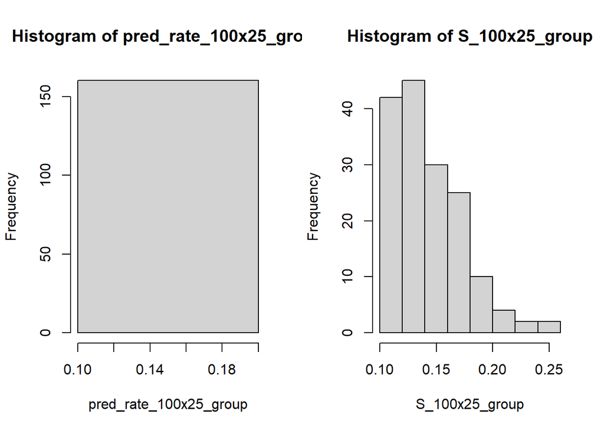

```
##    Min. 1st Qu.  Median    Mean 3rd Qu.    Max.
##    0.15    0.15    0.15    0.15    0.15    0.15
```

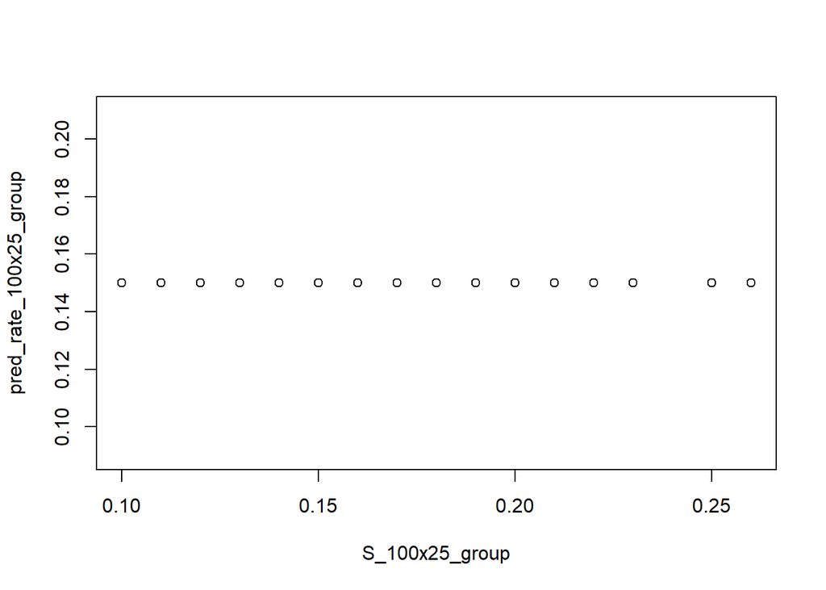

```
## [1] NA
```

```
## df_100x25_69
##         0.19
```

```
## df_100x25_14
##         0.11
```

```
##    Min. 1st Qu.  Median    Mean 3rd Qu.    Max.
##  0.1000  0.1200  0.1400  0.1458  0.1700  0.2600
```

```
##    B11_1 (.2)    B11_2 (.3)   B12_1 (-.1)   B12_2 (-.2)   B21d_1 (.8)
##   0.080092616   0.144867778  -0.180586740  -0.238723874   0.874663711
##   B21d_2 (.8)   B22d_1 (.4)   B22d_2 (.4)    B31_1 (.1)    B31_2 (.1)
##   0.898570716   0.148515776   0.019315233   0.337301701   0.260173917
##   B32_1 (-.1)   B32_2 (-.1)    Lmdd_1 (1)    Lmdd_2 (0)   Lmdd_3 (.4)
##  -0.116708331  -0.012856027   1.000000000   0.000000000   0.507014155
##    Lmdd_4 (0)   Lmdd_5 (.8)    Lmdd_6 (0)    Lmdd_7 (0)    Lmdd_8 (1)
##   0.000000000   0.749960303   0.000000000   0.000000000   1.000000000
##    Lmdd_9 (0)  Lmdd_10 (.5)   Lmdd_11 (0) Lmdd_12 (1.2)     Qd_1 (.2)
##   0.000000000   0.493518412   0.000000000   1.020018935   0.001000000
##     Qd_2 (.2)     Rd_1 (.3)     Rd_2 (.3)     Rd_3 (.3)     Rd_4 (.3)
##   0.001789137   0.103554651   0.049558803   0.069819093   0.053765245
##     Rd_5 (.3)     Rd_6 (.3)  gamma1 (3.5)  gamma2_1 (1)  gamma2_2 (1)
##   0.036543865   0.063330799   4.434597492   1.380151868   0.640825748
```

```
##    B11_1 (.2)    B11_2 (.3)   B12_1 (-.1)   B12_2 (-.2)   B21d_1 (.8)
##   0.187212199   0.347083151  -0.202424034  -0.305046678   0.839481473
##   B21d_2 (.8)   B22d_1 (.4)   B22d_2 (.4)    B31_1 (.1)    B31_2 (.1)
##   0.797016323   0.150622338   0.014257099  -0.488527656   0.385683894
##   B32_1 (-.1)   B32_2 (-.1)    Lmdd_1 (1)    Lmdd_2 (0)   Lmdd_3 (.4)
##  -0.198520377   0.263307482   1.000000000   0.000000000   0.451676071
##    Lmdd_4 (0)   Lmdd_5 (.8)    Lmdd_6 (0)    Lmdd_7 (0)    Lmdd_8 (1)
##   0.000000000   1.024229050   0.000000000   0.000000000   1.000000000
##    Lmdd_9 (0)  Lmdd_10 (.5)   Lmdd_11 (0) Lmdd_12 (1.2)     Qd_1 (.2)
##   0.000000000   0.567421913   0.000000000   1.093038440   0.002630429
##     Qd_2 (.2)     Rd_1 (.3)     Rd_2 (.3)     Rd_3 (.3)     Rd_4 (.3)
##   0.001000000   0.092773221   0.053006552   0.084236920   0.046031035
##     Rd_5 (.3)     Rd_6 (.3)  gamma1 (3.5)  gamma2_1 (1)  gamma2_2 (1)
##   0.056916952   0.052599300   4.360101700   1.237527490   1.974140525
```

```
##    B11_1 (.2)    B11_2 (.3)   B12_1 (-.1)   B12_2 (-.2)   B21d_1 (.8)
##    0.16406077    0.21963556   -0.16727749   -0.18653193    0.81463796
##   B21d_2 (.8)   B22d_1 (.4)   B22d_2 (.4)    B31_1 (.1)    B31_2 (.1)
##    0.83458311    0.24055503    0.21741268    0.06782755    0.06056209
##   B32_1 (-.1)   B32_2 (-.1)    Lmdd_1 (1)    Lmdd_2 (0)   Lmdd_3 (.4)
##   -0.07473773   -0.07869535    1.00000000    0.00000000    0.83104066
##    Lmdd_4 (0)   Lmdd_5 (.8)    Lmdd_6 (0)    Lmdd_7 (0)    Lmdd_8 (1)
##    0.00000000    0.94883604    0.00000000    0.00000000    1.00000000
##    Lmdd_9 (0)  Lmdd_10 (.5)   Lmdd_11 (0) Lmdd_12 (1.2)     Qd_1 (.2)
##    0.00000000    0.84418567    0.00000000    1.11060149    0.11515086
##     Qd_2 (.2)     Rd_1 (.3)     Rd_2 (.3)     Rd_3 (.3)     Rd_4 (.3)
##    0.11490248    0.28078805    0.27181109    0.27370766    0.28501720
##     Rd_5 (.3)     Rd_6 (.3)  gamma1 (3.5)  gamma2_1 (1)  gamma2_2 (1)
##    0.27237317    0.28005407    4.22496324    0.94262793    0.92880402
```

```
##    B11_1 (.2)    B11_2 (.3)   B12_1 (-.1)   B12_2 (-.2)   B21d_1 (.8)
##    0.13185193    0.19659086   -0.14595535   -0.17651852    0.83232126
##   B21d_2 (.8)   B22d_1 (.4)   B22d_2 (.4)    B31_1 (.1)    B31_2 (.1)
##    0.85757574    0.25694798    0.22394773    0.04632495    0.05034045
##   B32_1 (-.1)   B32_2 (-.1)    Lmdd_1 (1)    Lmdd_2 (0)   Lmdd_3 (.4)
##   -0.07913927   -0.06332214    1.00000000    0.00000000    0.83706674
##    Lmdd_4 (0)   Lmdd_5 (.8)    Lmdd_6 (0)    Lmdd_7 (0)    Lmdd_8 (1)
##    0.00000000    0.91617522    0.00000000    0.00000000    1.00000000
##    Lmdd_9 (0)  Lmdd_10 (.5)   Lmdd_11 (0) Lmdd_12 (1.2)     Qd_1 (.2)
##    0.00000000    0.80073929    0.00000000    1.12335938    0.17287733
##     Qd_2 (.2)     Rd_1 (.3)     Rd_2 (.3)     Rd_3 (.3)     Rd_4 (.3)
##    0.17235257    0.37461500    0.37352838    0.37305085    0.37395401
##     Rd_5 (.3)     Rd_6 (.3)  gamma1 (3.5)  gamma2_1 (1)  gamma2_2 (1)
##    0.37361611    0.37296443    4.12372112    0.85946706    0.81179604
```

```
##    B11_1 (.2)    B11_2 (.3)   B12_1 (-.1)   B12_2 (-.2)   B21d_1 (.8)
##    0.12341669    0.12724292    0.11551840    0.12083192    0.09447184
##   B21d_2 (.8)   B22d_1 (.4)   B22d_2 (.4)    B31_1 (.1)    B31_2 (.1)
##    0.09262592    0.13927883    0.14330599    0.13568238    0.12343225
##   B32_1 (-.1)   B32_2 (-.1)    Lmdd_1 (1)    Lmdd_2 (0)   Lmdd_3 (.4)
##    0.10236949    0.10528691    0.00000000    0.00000000    0.31363457
##    Lmdd_4 (0)   Lmdd_5 (.8)    Lmdd_6 (0)    Lmdd_7 (0)    Lmdd_8 (1)
##    0.00000000    0.21601009    0.00000000    0.00000000    0.00000000
##    Lmdd_9 (0)  Lmdd_10 (.5)   Lmdd_11 (0) Lmdd_12 (1.2)     Qd_1 (.2)
##    0.00000000    0.28639095    0.00000000    0.22799347    0.08146046
##     Qd_2 (.2)     Rd_1 (.3)     Rd_2 (.3)     Rd_3 (.3)     Rd_4 (.3)
##    0.08136988    0.13399206    0.14468668    0.14095288    0.13232451
##     Rd_5 (.3)     Rd_6 (.3)  gamma1 (3.5)  gamma2_1 (1)  gamma2_2 (1)
##    0.14441294    0.13229746    0.16839742    0.55499328    0.56045949
```